# Informe QFD - Casa de la Calidad

Juan Carlos Almachi Nacimba

# 1 Introducción

La Casa de la Calidad es una herramienta fundamental dentro del Despliegue de la Función de Calidad (QFD, por sus siglas en inglés). Su propósito es traducir los requerimientos del cliente (la voz del cliente) en especificaciones técnicas o ingenieriles que guíen el diseño y desarrollo del producto.

Se representa gráficamente como una matriz que relaciona “Qué se quiere” (requisitos del cliente) con “Cómo lograrlo” (características técnicas del producto). Esta matriz ayuda a priorizar las acciones de diseño y tomar decisiones fundamentadas en lo que realmente agrega valor desde la perspectiva del cliente.

# 2 Descripción de la matriz

La matriz principal contiene: - Requisitos del cliente en filas (WHATs). - Características técnicas del producto en columnas (HOWs). - Relaciones entre ambos en la intersección, con símbolos o puntuaciones que indican la fuerza del vínculo. - Peso de importancia por cada requerimiento. - Dificultad de implementación de cada característica. - Correlaciones entre los HOWs representadas en el “techo” de la casa.

# 3 Descargar el archivo original

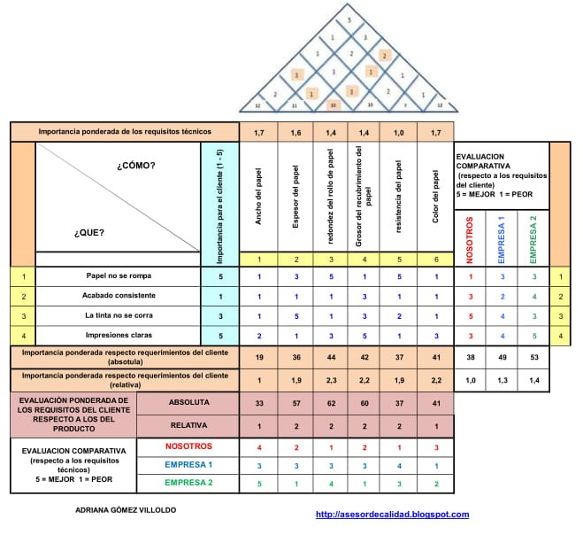

*Figura 1. Haga clic sobre la imagen para descargarla.*